# AE 21: Multiple Regression, cont

STA 199

3/29/2022

## Coming up

- Peer Review Due Friday at 9 PM.
- Exam 2 released on Friday morning, due next Tuesday at 11:59 PM.
- There will not be lab on Monday next week or class on Tuesday.

## Main ideas

- Review and expand upon concepts from our first three regression classes.
- Learn how to carry out and interpret multiple linear regressions.
- Learn how to assess the conditions for inference in regression.

## Packages

We’ll use the `tidyverse`, `broom`, `fivethirtyeight`, and `viridis` packages again, as well as the `car` package when calculate variance inflation factors (VIFs) to examine whether our models have multicollinearity.

## Please recall

- Response Variable: Variable whose behavior or variation you are trying to understand, on the y-axis. Also called the dependent variable.
- Explanatory Variable: Other variables that you want to use to explain the variation in the response, on the x-axis. Also called independent variables, predictors, or features.
- Predicted value: Output of the model function
  - The model function gives the typical value of the response variable conditioning on the explanatory variables (what does this mean?)
- Residuals: Shows how far each case is from its predicted value
  - Residual = Observed value - Predicted value
  - Tells how far above/below the model function each case is

## The linear model with a single predictor

- We’re interested in the $\beta_0$ (population parameter for the intercept) and the $\beta_1$ (population parameter for the slope) in the following model:

$$\hat{y} = \beta_0 + \beta_1~x + \epsilon$$

- Unfortunately, we can’t get these values
- So we use sample statistics to estimate them:

$$\hat{y} = b_0 + b_1~x$$

## Least squares regression

The regression line minimizes the sum of squared residuals.

- **Residuals**: $e_i = y_i - \hat{y}_i$,
- The regression line minimizes $\sum_{i = 1}^n e_i^2$.
- Equivalently, minimizing $\sum_{i = 1}^n [y_i - (b_0 + b_1~x_i)]^2$

## Data: A Closer Look

```r
sports_car_prices <- read.csv("sportscars.csv")
```

The file `sportscars.csv` contains prices for Porsche and Jaguar cars for sale on cars.com.

`car`: car make (Jaguar or Porsche)

`price`: price in USD

`age`: age of the car in years

`mileage`: previous miles driven

## The linear model with a single predictor

```r
prices_model <- linear_reg() %>%
  set_engine("lm") %>%
  fit(price ~ age, data = sports_car_prices)
tidy(prices_model)
```

```
## # A tibble: 2 × 5
##   term        estimate std.error statistic  p.value
##   <chr>          <dbl>     <dbl>     <dbl>    <dbl>
## 1 (Intercept)   53246.     3322.     16.0  5.70e-23
## 2 age           -2149.      466.     -4.62 2.22e- 5
```

But is the age the only variable that predicts price?

## The linear model with multiple predictors

$$\hat{y} = \beta_0 + \beta_1~x_1 + \beta_2~x_2 + \cdots + \beta_k~x_k +\epsilon$$

- Sample model that we use to estimate the population model:

$$\hat{y} = b_0 + b_1~x_1 + b_2~x_2 + \cdots + b_k~x_k$$

Let’s add a variable.

## Price vs. age and type of car

Does the relationship between price and age depend on type of car?

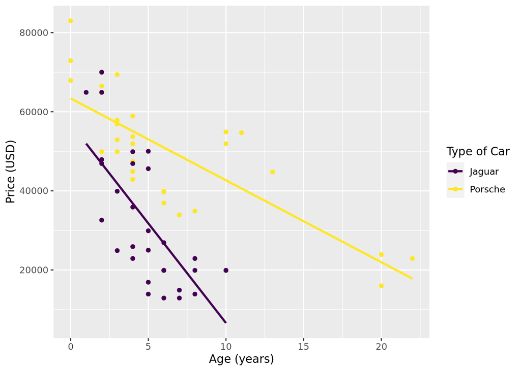

## Modeling with main effects

```r
m_main <- linear_reg() %>%
  set_engine("lm") %>%
  fit(price ~ age + car, data = sports_car_prices)
m_main %>%
  tidy() %>%
  select(term, estimate)
```

```
## # A tibble: 3 × 2
##   term        estimate
##   <chr>          <dbl>
## 1 (Intercept)   44310.
## 2 age           -2487.
## 3 carPorsche    21648.
```

Linear model:

$$\widehat{price} = 44310 - 2487~age + 21648~carPorsche$$

- Plug in 0 for `carPorsche` to get the linear model for Jaguars.
- Plug in 1 for `carPorsche` to get the linear model for Porsches.
- Jaguar:

$$\widehat{price} = 44310 - 2487~age + 21648* 0 \\
=44310-2487*age$$

- Porsche:
  $$\widehat{price} = 44310 - 2487~age + 21648* 1 \\
  =65958 - 2487~age$$
- Rate of change in price as the age of the car increases does not depend on make of car (same slopes)
- Porsches are consistently more expensive than Jaguars (different intercepts)

## Interpretation of main effects

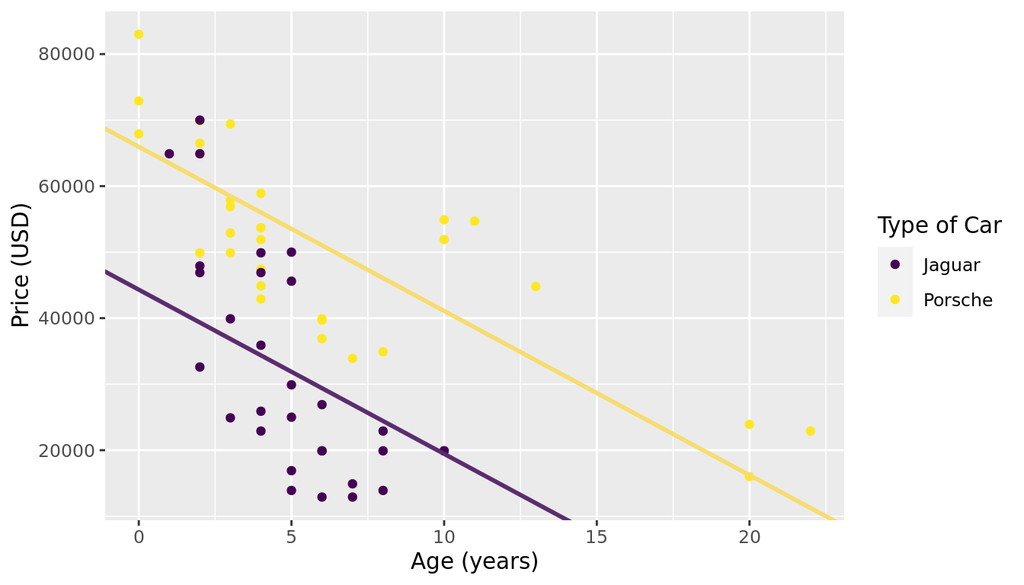

## Main effects, numerical and categorical predictors

```r
m_main %>%
  tidy() %>%
  select(term, estimate)
```

```
## # A tibble: 3 × 2
##   term        estimate
##   <chr>          <dbl>
## 1 (Intercept)   44310.
## 2 age           -2487.
## 3 carPorsche    21648.
```

```r
m_main_coefs <- m_main %>%
  tidy() %>%
  select(term, estimate)
m_main_coefs
```

```
## # A tibble: 3 × 2
##   term        estimate
##   <chr>          <dbl>
## 1 (Intercept)   44310.
## 2 age           -2487.
## 3 carPorsche    21648.
```

- **All else held constant**, for each additional year of a car’s age, the price of the car is predicted to decrease, on average, by $2,487.
- **All else held constant**, Porsches are predicted, on average, to have a price that is $21,648 greater than Jaguars.
- Jaguars that have an age of 0 are predicted, on average, to have a price of $44,310.

## What went wrong?

**Question**: Why is our linear regression model different from what we got from `geom_smooth(method = "lm")`?

- `car` is the only variable in our model that affects the intercept.
- The model we specified assumes Jaguars and Porsches have the **same slope** and **different intercepts**.
- What is the most appropriate model for these data?
  - same slope and intercept for Jaguars and Porsches?
  - same slope and different intercept for Jaguars and Porsches?
  - different slope and different intercept for Jaguars and Porsches?

## Interacting explanatory variables

- Including an interaction effect in the model allows for different slopes, i.e. nonparallel lines.
- This means that the relationship between an explanatory variable and the response depends on another explanatory variable.
- We can accomplish this by adding an **interaction variable**. This is the product of two explanatory variables (also sometimes called an interaction term).

## Modeling with interaction effects

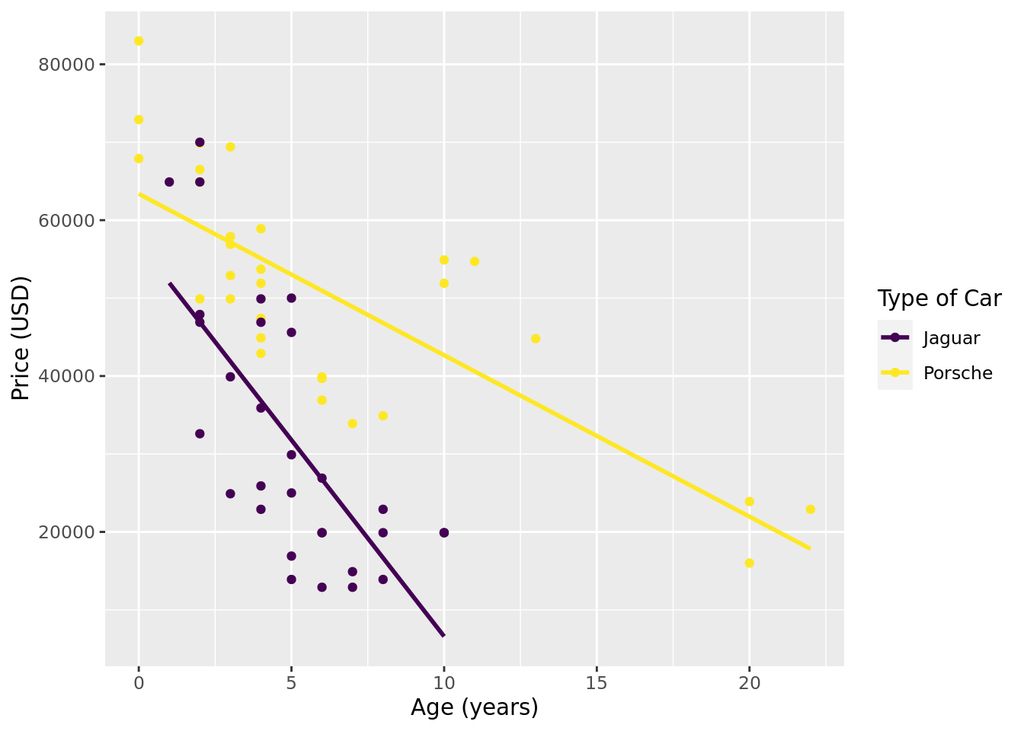

```r
ggplot(data = sports_car_prices,
       aes(x = age, y = price, color = car)) +
    scale_color_viridis(discrete = TRUE, option = "D", name = "Type of Car") +
  labs(x = "Age (years)", y = "Price (USD)", color = "Car Make") +
  geom_point() +
  geom_smooth(method="lm", se = FALSE)
```

```r
 m_int <- linear_reg() %>%
  set_engine("lm") %>%
  fit(price ~ age + car + age * car,
            data = sports_car_prices)
m_int %>%
  tidy() %>%
  select(term, estimate)
```

```
## # A tibble: 4 × 2
##   term           estimate
##   <chr>             <dbl>
## 1 (Intercept)      56988.
## 2 age              -5040.
## 3 carPorsche        6387.
## 4 age:carPorsche    2969.
```

$$\widehat{price} = 56988 - 5040~age + 6387~carPorsche + 2969~age \times carPorsche$$

## Interpretation of interaction effects

$$\widehat{price} = 56988 - 5040~age + 6387~carPorsche + 2969~age \times carPorsche$$

- Plug in 0 for `carPorsche` to get the linear model for Jaguars.
- Plug in 1 for `carPorsche` to get the linear model for Porsches.
- Jaguar:

$$\begin{align}\widehat{price} &= 56988 - 5040~age + 6387~carPorsche + 2969~age \times carPorsche \\
&= 56988 - 5040~age + 6387 \times 0 + 2969~age \times 0\\
&= 56988 - 5040~age\end{align}$$

- Porsche:

$$\begin{align}\widehat{price} &= 56988 - 5040~age + 6387~carPorsche + 2969~age \times carPorsche \\
&= 56988 - 5040~age + 6387 \times 1 + 2969~age \times 1\\
&= 63375 - 2071~age\end{align}$$

## Interpretation of interaction effects

- Jaguar:

$$\widehat{price} = 56988 - 5040~age$$

- Porsche:

$$\widehat{price} = 63375 - 2071~age$$

- Rate of change in price as the age of the car increases depends on the make of the car (different slopes).
- Porsches are consistently more expensive than Jaguars (different intercepts).

## Continuous by continuous interactions

- Interpretation becomes trickier
- Slopes conditional on values of explanatory variables

## Third order interactions

- Can you? Yes
- Should you? Probably not if you want to interpret these interactions in context of the data.

## Multicollinearity

You don’t want the predictors to be too correlated with each other in a multiple regression model. When they are correlated with each other, you have **mutlicollinearity**. One way to diagnose multicollinearity is with **variance inflation factors.** There’s no specific cutoff, but a VIF of 10 if sometimes used as a cutoff.

Let’s see if we have multicollinearity in our first model. (Please do not run linear regressions this way on the exam, I’m doing it this way to demonstrate with `car`.)

```r
m_main_2 <- lm(price ~ age + car, data = sports_car_prices)
tibble(vif(m_main_2))
```

```
## # A tibble: 2 × 1
##   `vif(m_main_2)`
##             <dbl>
## 1            1.02
## 2            1.02
```

Now, let’s check if for the interactive model.

```r
m_int_2 <- lm(price ~ age + car + age * car,
            data = sports_car_prices)
tibble(vif(m_int_2))
```

```
## # A tibble: 3 × 1
##   `vif(m_int_2)`
##            <dbl>
## 1           7.27
## 2           3.85
## 3          11.2
```

Notice the VIFs here are higher. This is to be expected with an interactive model.

**Question**: Why do you think VIFs will be higher in interactive models?

Yes- this is because the interaction terms are made up of the other variables. So, they are likely to correlate with them. This is normal.

## P-Hacking

Let’s return to the candy rankings data:

Notice below that our p-value for the sugar percentile variable is **REALLY CLOSE** to 0.05. While arbitrary, this threshold is important in statistics and is sometimes used as the cutoff to determine whether results are publishable.

```r
candy_rankings <- candy_rankings %>%
  mutate(sugarpercent100 = sugarpercent * 100)
candy <- linear_reg() %>%
  set_engine("lm") %>%
  fit(winpercent ~ sugarpercent100 + chocolate, data = candy_rankings)
tidy(candy)
```

```
## # A tibble: 3 × 5
##   term            estimate std.error statistic  p.value
##   <chr>              <dbl>     <dbl>     <dbl>    <dbl>
## 1 (Intercept)      38.3       2.55       15.0  3.31e-25
## 2 sugarpercent100   0.0857    0.0435      1.97 5.25e- 2
## 3 chocolateTRUE    18.3       2.47        7.40 1.06e-10
```

[FiveThirtyEight](https://projects.fivethirtyeight.com/p-hacking) has a interactive page showing how you can p-hack your way to publication.

How could we p-hack our way to a significant result for the sugar variable?

Try adding the variable for whether the variable is a hard candy.

**Question**: Why is p-hacking problematic?

This can result in you getting statistically significant results when you may not actually have them, increasing the probability of a Type 1 Error, among other concerns.

## Practice

1. Run and interpret a multiple regression with both age and mileage as predictors. Are both of these statistically significant predictors of the price of a car?

Slopes:

Intercept:

2. (To Review) Find and interpret the adjusted $R^2$ for this model.
3. Examine the extent to which there is multicollinearity in this model.

- `Ozone`: ozone (ppb)
- `Solar.R`: solar radiation (langleys)
- `Wind`: wind (mph)
- `Temp`: temperature (degrees F)

```r
airquality <- read.csv("airquality.csv")
```

4. Please run and interpret a model with ozone in parts per billion as the response variable and solar radiation, wind, and temperature as the explanatory variables.

Slopes:

Intercept: